# IODS course project

practising123

# Chapter 1. - About the project

Introduction to Open Data Science 2018 is a Massive Online Open Course(Mooc) which teaches the basics of data science, tools needed (like GitHub and RStudio) and languages like R. Course teaches about the amount, importance and possibilities of data. Course highlights open data and open source free software. This is a link to my GitHub repository: https://github.com/practising123/IODS-project

# Chapter 2 - Regression and model validation

- Did the dataCamp exercises.

# Wrangling code:

```r
library(dplyr)
library(ggplot2)
library(GGally)
lrn14 <- read.table("http://www.helsinki.fi/~kvehkala/JYTmooc/JYTOPKYS3-
data.txt", sep="\t", header=TRUE)
dim(lrn14)
```

```
## [1] 183  60
```

```r
str(lrn14)
```

```
## 'data.frame':    183 obs. of  60 variables:
##  $ Aa      : int  3 2 4 4 3 4 4 3 2 3 ...
##  $ Ab      : int  1 2 1 2 2 2 1 1 1 2 ...
##  $ Ac      : int  2 2 1 3 2 1 2 2 2 1 ...
##  $ Ad      : int  1 2 1 2 1 1 2 1 1 1 ...
##  $ Ae      : int  1 1 1 1 2 1 1 1 1 1 ...
##  $ Af      : int  1 1 1 1 1 1 1 1 1 2 ...
##  $ ST01    : int  4 4 3 3 4 4 5 4 4 4 ...
##  $ SU02    : int  2 2 1 3 2 3 2 2 1 2 ...
##  $ D03     : int  4 4 4 4 5 5 4 4 5 4 ...
##  $ ST04    : int  4 4 4 4 3 4 2 5 5 4 ...
##  $ SU05    : int  2 4 2 3 4 3 2 4 2 4 ...
##  $ D06     : int  4 2 3 4 4 5 3 3 4 4 ...
##  $ D07     : int  4 3 4 4 4 5 4 4 5 4 ...
##  $ SU08    : int  3 4 1 2 3 4 4 2 4 2 ...
```

[output cut: 46 more lines]

- Reading the table from web and saving to lrn14. 183 rows/persons, 60 variables.

```r
deep_questions <- c("D03", "D11", "D19", "D27", "D07", "D14", "D22", "D30","D06",  "D15", "D23", "D31")
deep_columns <- select(lrn14, one_of(deep_questions))
deep <- rowMeans((deep_columns))
surface_questions <- c("SU02","SU10","SU18","SU26", "SU05","SU13","SU21","SU29","SU08","SU16","SU24","SU32")
surface_columns <- select(lrn14, one_of(surface_questions))
surf <- rowMeans(surface_columns)
strategic_questions <- c("ST01","ST09","ST17","ST25","ST04","ST12","ST20","ST28")
strategic_columns <- select(lrn14, one_of(strategic_questions))
stra <- rowMeans(strategic_columns)
```

- Taking courses(in deep, strategic…) and counting their means to create new combination variables.

```r
keep_columns <- c("gender","Age","Attitude", "Points")
learning2014 <- select(lrn14, one_of(keep_columns))
```

- Decide columns to take and retrieve all of them to “learning2014”
- Choosing the columns, creating new data frame learning2014 for analyzing.

```r
learning2014$deep <- deep
learning2014$stra <- stra
learning2014$surf <- surf
learning2014 <-filter(learning2014, Points>0)
str(learning2014)
```

```
## 'data.frame':    166 obs. of  7 variables:
##  $ gender  : Factor w/ 2 levels "F","M": 1 2 1 2 2 1 2 1 2 1 ...
##  $ Age     : int  53 55 49 53 49 38 50 37 37 42 ...
##  $ Attitude: int  37 31 25 35 37 38 35 29 38 21 ...
##  $ Points  : int  25 12 24 10 22 21 21 31 24 26 ...
##  $ deep    : num  3.58 2.92 3.5 3.5 3.67 ...
##  $ stra    : num  3.38 2.75 3.62 3.12 3.62 ...
##  $ surf    : num  2.58 3.17 2.25 2.25 2.83 ...
```

```r
dim(learning2014)
```

```
## [1] 166   7
```

- Insert compilation variables and filtering zero-pointers. Now we have Learning table with keep columns and combination columns.

```r
write.table(learning2014, file = "data/learning2014.txt", row.names = TRUE)

new_table <- read.table(file = "data/learning2014.txt", header=TRUE)
dim(new_table)
```

```
## [1] 166   7
```

```r
str(new_table)
```

```
## 'data.frame':    166 obs. of  7 variables:
##  $ gender  : Factor w/ 2 levels "F","M": 1 2 1 2 2 1 2 1 2 1 ...
##  $ Age     : int  53 55 49 53 49 38 50 37 37 42 ...
##  $ Attitude: int  37 31 25 35 37 38 35 29 38 21 ...
##  $ Points  : int  25 12 24 10 22 21 21 31 24 26 ...
##  $ deep    : num  3.58 2.92 3.5 3.5 3.67 ...
##  $ stra    : num  3.38 2.75 3.62 3.12 3.62 ...
##  $ surf    : num  2.58 3.17 2.25 2.25 2.83 ...
```

- Saving and loading from /data

# Analysis

2.1

```r
new_table <- read.table(file = "data/learning2014.txt", header=TRUE)
summary(new_table)
```

```
##  gender       Age           Attitude         Points           deep
##  F:110   Min.   :17.00   Min.   :14.00   Min.   : 7.00   Min.   :1.583
##  M: 56   1st Qu.:21.00   1st Qu.:26.00   1st Qu.:19.00   1st Qu.:3.333
##          Median :22.00   Median :32.00   Median :23.00   Median :3.667
##          Mean   :25.51   Mean   :31.43   Mean   :22.72   Mean   :3.680
##          3rd Qu.:27.00   3rd Qu.:37.00   3rd Qu.:27.75   3rd Qu.:4.083
##          Max.   :55.00   Max.   :50.00   Max.   :33.00   Max.   :4.917
##       stra            surf
##  Min.   :1.250   Min.   :1.583
##  1st Qu.:2.625   1st Qu.:2.417
##  Median :3.188   Median :2.833
##  Mean   :3.121   Mean   :2.787
##  3rd Qu.:3.625   3rd Qu.:3.167
##  Max.   :5.000   Max.   :4.333
```

- The data contains study information on 166 individuals, with 7 variables: Age(years), gender (F/M), Attitude, points, deep, stra and surf.
- Attitude is mean of answers on multiple questions measuring students attitude towards statistics.
- Deep, stra and surf are means of multiple questions measuring these subjects.
- Points is exam points.

2.2

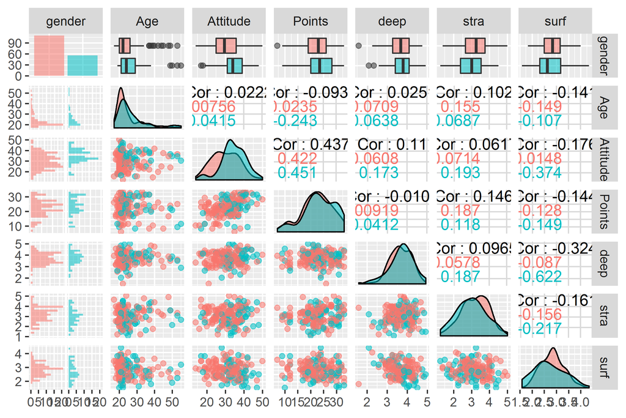

```r
p <- ggpairs(new_table, mapping = aes(col=gender, alpha=0.3), lower = list(combo = wrap("facethist", bins = 20)))
p
```

- Creates the plot of new_table and prints it.

```r
table(cut(new_table$Age, breaks = seq(15,55,by=10)))
```

```
##
## (15,25] (25,35] (35,45] (45,55]
##     116      32      11       7
```

```r
table(new_table$gender, cut(new_table$Attitude, breaks = seq(1,56,by=5)))
```

```
##
##     (1,6] (6,11] (11,16] (16,21] (21,26] (26,31] (31,36] (36,41] (41,46]
##   F     0      0       2      15      23      22      26      17       3
##   M     0      0       0       3       2      11      17      17       4
##
##     (46,51] (51,56]
##   F       2       0
##   M       2       0
```

2.3

```r
my_model <- lm(Points ~ Attitude + stra + surf, data = new_table)
summary(my_model)
```

```
##
## Call:
## lm(formula = Points ~ Attitude + stra + surf, data = new_table)
##
## Residuals:
##      Min       1Q   Median       3Q      Max
## -17.1550  -3.4346   0.5156   3.6401  10.8952
##
## Coefficients:
##             Estimate Std. Error t value Pr(>|t|)
## (Intercept) 11.01711    3.68375   2.991  0.00322 **
## Attitude     0.33952    0.05741   5.913 1.93e-08 ***
## stra         0.85313    0.54159   1.575  0.11716
## surf        -0.58607    0.80138  -0.731  0.46563
## ---
## Signif. codes:  0 '***' 0.001 '**' 0.01 '*' 0.05 '.' 0.1 ' ' 1
##
## Residual standard error: 5.296 on 162 degrees of freedom
## Multiple R-squared:  0.2074, Adjusted R-squared:  0.1927
## F-statistic: 14.13 on 3 and 162 DF,  p-value: 3.156e-08
```

- Attitude having 0.34 regression to points is significant, attitude has ***
- Multiple R-squared: 0.21 and 0.34 regression.
- Dropping stra and surf because those are not relevant.

```r
my_model <- lm(Points ~ Attitude, data = new_table)
```

2.4

```r
summary(my_model)
```

```
##
## Call:
## lm(formula = Points ~ Attitude, data = new_table)
##
## Residuals:
##      Min       1Q   Median       3Q      Max
## -16.9763  -3.2119   0.4339   4.1534  10.6645
##
## Coefficients:
##             Estimate Std. Error t value Pr(>|t|)
## (Intercept) 11.63715    1.83035   6.358 1.95e-09 ***
## Attitude     0.35255    0.05674   6.214 4.12e-09 ***
## ---
## Signif. codes:  0 '***' 0.001 '**' 0.01 '*' 0.05 '.' 0.1 ' ' 1
##
## Residual standard error: 5.32 on 164 degrees of freedom
## Multiple R-squared:  0.1906, Adjusted R-squared:  0.1856
## F-statistic: 38.61 on 1 and 164 DF,  p-value: 4.119e-09
```

- Multiple R-squared: 0.19 and 0.35 regression. predictors explain 19% of variance. 1 point in attitude raises exam points by 0.353 on average.

```r
my_model <- lm(Points ~ Attitude, data = new_table)
summary(my_model)
```

```
##
## Call:
## lm(formula = Points ~ Attitude, data = new_table)
##
## Residuals:
##      Min       1Q   Median       3Q      Max
## -16.9763  -3.2119   0.4339   4.1534  10.6645
##
## Coefficients:
##             Estimate Std. Error t value Pr(>|t|)
## (Intercept) 11.63715    1.83035   6.358 1.95e-09 ***
## Attitude     0.35255    0.05674   6.214 4.12e-09 ***
## ---
## Signif. codes:  0 '***' 0.001 '**' 0.01 '*' 0.05 '.' 0.1 ' ' 1
##
## Residual standard error: 5.32 on 164 degrees of freedom
## Multiple R-squared:  0.1906, Adjusted R-squared:  0.1856
## F-statistic: 38.61 on 1 and 164 DF,  p-value: 4.119e-09
```

2.5 - Assumptions of linear regression models:

- The errors are normally distributed
- The errors are not correlated
- The errors have constant variance
- The size of a given error does not depend on the explanatory variables

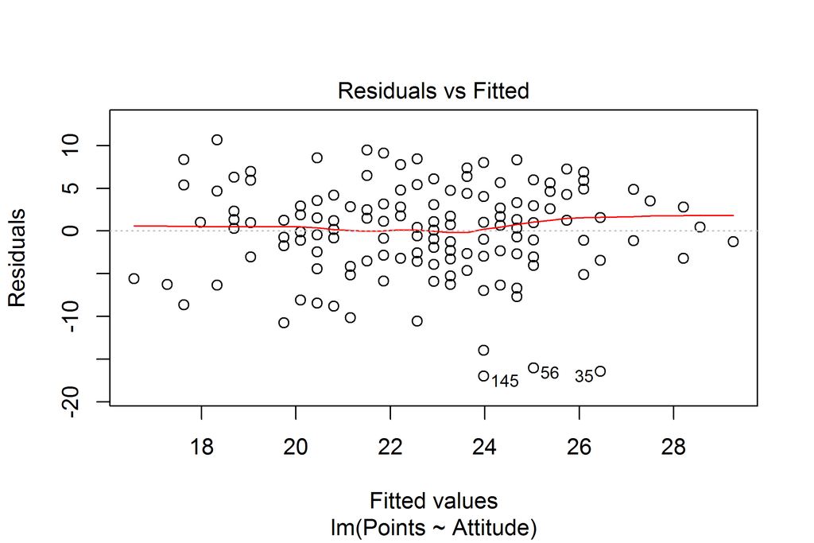

```r
plot(my_model, which =c(1))
```

- Residual vs fitted. Tells if there are patterns, patterns mean problem with the assumption. If there would be bigger residual on bigger values, the assumption(my_model) would need to be corrected. Residuals seem to be scattered evenly(variance seems constant).

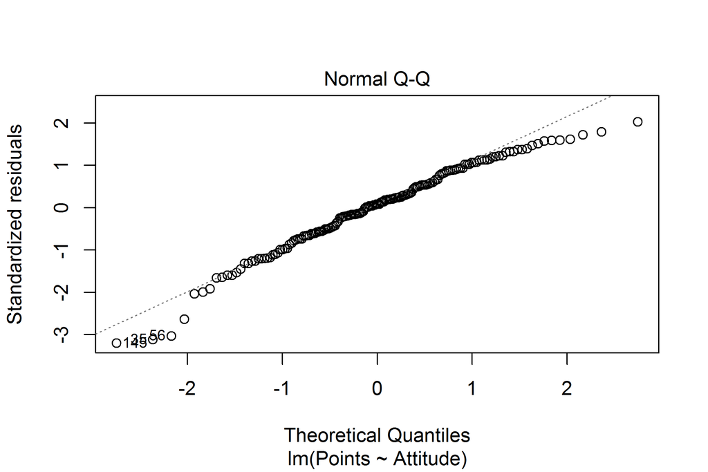

```r
plot(my_model, which =c(2))
```

- The Q-Q-plot most of the points are on line with little mix in the ends. Shows the error assumption. Seems good enough,

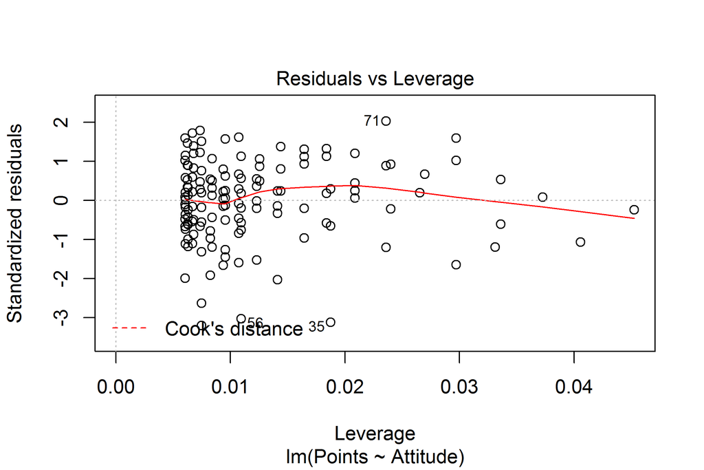

```r
plot(my_model, which =c(5))
```

- Tells if there are influentical cases in the model. if there are cases on top right or bottom right, those would strongly influence the results.

# Chapter 3 - Logistic regression

- Did the dataCamp exercises.

3.1 & 3.2

```r
library(GGally)
library(dplyr)
library(tidyr)
library(ggplot2)
alc <- read.table("data/alc.csv",header = TRUE)
colnames(alc)
```

```
##  [1] "school"     "sex"        "age"        "address"    "famsize"
##  [6] "Pstatus"    "Medu"       "Fedu"       "Mjob"       "Fjob"
## [11] "reason"     "nursery"    "internet"   "guardian"   "traveltime"
## [16] "studytime"  "failures"   "schoolsup"  "famsup"     "paid"
## [21] "activities" "higher"     "romantic"   "famrel"     "freetime"
## [26] "goout"      "Dalc"       "Walc"       "health"     "absences"
## [31] "G1"         "G2"         "G3"         "alc_use"    "high_use"
```

The data is combination of two guestionaires made in portugal about school performance and alcohol usage. The two tables are combined to alc, data has 35 variables and 382 observations. Downloading the data and more information here: the tables are Student performansce data that can be studied or downloaded here: https://archive.ics.uci.edu/ml/datasets/Student+Performance . In addition: - The variables not used for joining the two data have been combined by averaging (including the grade variables) - ‘alc_use’ is the average of ‘Dalc’ and ‘Walc’ - ‘high_use’ is TRUE if ‘alc_use’ is higher than 2 and FALSE otherwise

3.3 The 4 hypothesis and interesting varibles I chose to explore are: absences, My guess is that more absences from school would lead to higher alcohol use because of lower grades and “rebellious” nature of the person. sex, hypothesis is that male will drink heavier than female. pstatus, hypothesis is that child of a divorced parents is more likely to be high user. G3(final grade) hypothesis is that high users are likely to get lower final score than low users. 3.4

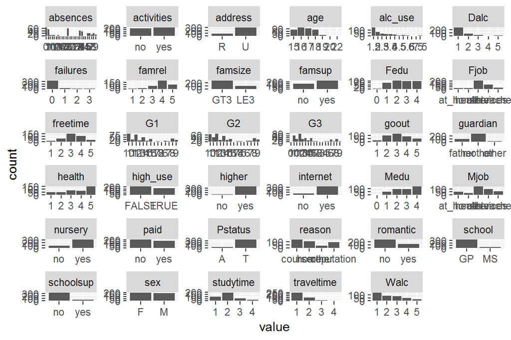

```r
gather(alc) %>% ggplot(aes(value)) + facet_wrap("key", scales = "free") + geom_bar()
```

```r
alc %>% group_by(high_use, absences) %>% summarise(count = n())
```

```
## # A tibble: 42 x 3
## # Groups:   high_use [?]
##    high_use absences count
##    <lgl>       <int> <int>
##  1 FALSE           0    43
##  2 FALSE           1    29
##  3 FALSE           2    33
##  4 FALSE           3    28
##  5 FALSE           4    19
##  6 FALSE           5    11
##  7 FALSE           6    13
##  8 FALSE           7     5
##  9 FALSE           8     9
## 10 FALSE           9     4
## # ... with 32 more rows
```

```r
alc %>% group_by(high_use, sex) %>% summarise(count = n())
```

```
## # A tibble: 4 x 3
## # Groups:   high_use [?]
##   high_use sex   count
##   <lgl>    <fct> <int>
## 1 FALSE    F       129
## 2 FALSE    M        79
## 3 TRUE     F        69
## 4 TRUE     M       105
```

```r
alc %>% group_by( Pstatus, high_use) %>% summarise(count = n())
```

```
## # A tibble: 4 x 3
## # Groups:   Pstatus [?]
##   Pstatus high_use count
##   <fct>   <lgl>    <int>
## 1 A       FALSE       24
## 2 A       TRUE        14
## 3 T       FALSE      184
## 4 T       TRUE       160
```

```r
alc %>% group_by(G3, high_use) %>% summarise(count = n())
```

```
## # A tibble: 32 x 3
## # Groups:   G3 [?]
##       G3 high_use count
##    <int> <lgl>    <int>
##  1     0 TRUE         2
##  2     2 TRUE         1
##  3     3 FALSE        1
##  4     4 FALSE        2
##  5     4 TRUE         5
##  6     5 FALSE        4
##  7     5 TRUE         2
##  8     6 FALSE       13
##  9     6 TRUE         9
## 10     7 FALSE        2
## # ... with 22 more rows
```

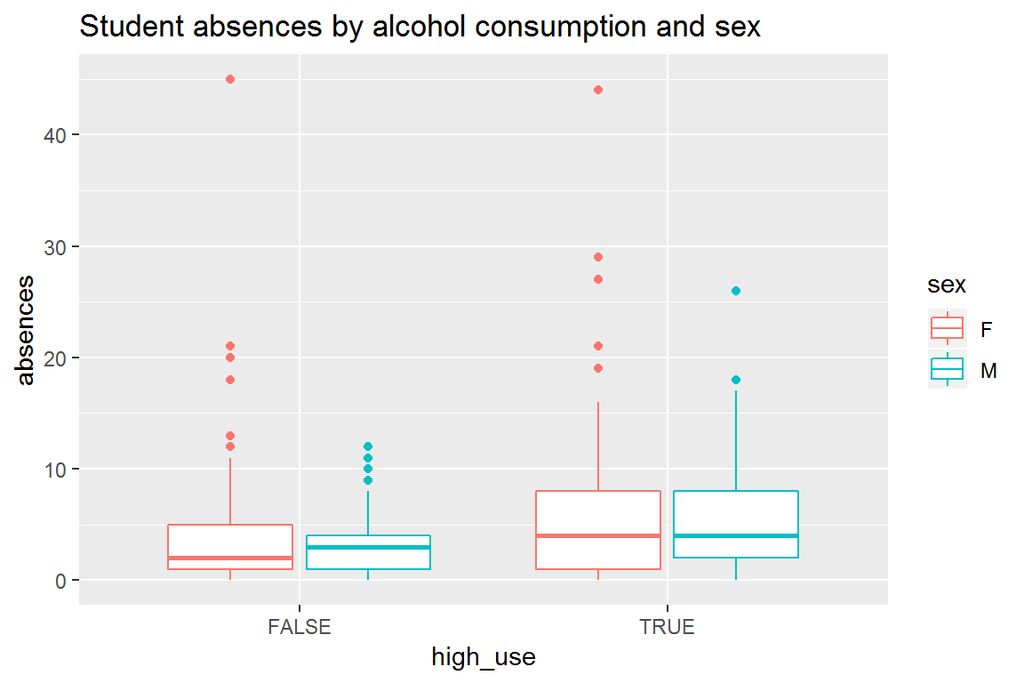

```r
g1 <- ggplot(alc, aes(x = high_use, y = absences, col=sex))
g1 + geom_boxplot() + ggtitle("Student absences by alcohol consumption and sex")
```

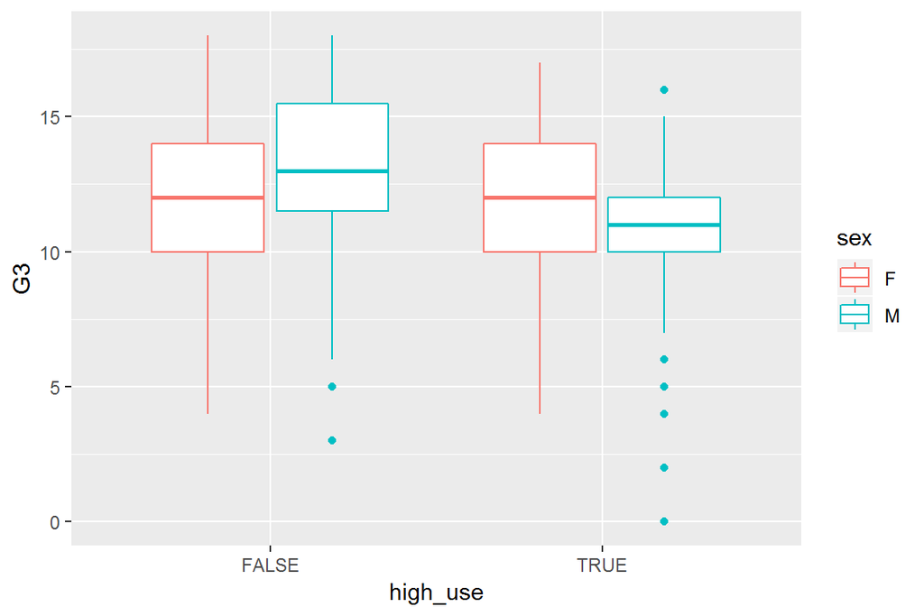

```r
g2 <- ggplot(alc, aes(x = high_use, y = G3, col=sex))
g2 + geom_boxplot()
```

```r
m <- glm(high_use ~ absences + sex + Pstatus + G3, data = alc, family = "binomial")
summary(m)
```

```
##
## Call:
## glm(formula = high_use ~ absences + sex + Pstatus + G3, family = "binomial",
##     data = alc)
##
## Deviance Residuals:
##     Min       1Q   Median       3Q      Max
## -2.1325  -1.0311  -0.7191   1.0860   1.8230
##
## Coefficients:
##             Estimate Std. Error z value Pr(>|z|)
## (Intercept) -0.53893    0.57856  -0.932 0.351590
## absences     0.07836    0.02306   3.399 0.000677 ***
## sexM         0.98733    0.21860   4.517 6.28e-06 ***
## PstatusT     0.51433    0.38235   1.345 0.178563
## G3          -0.08223    0.03368  -2.442 0.014622 *
## ---
## Signif. codes:  0 '***' 0.001 '**' 0.01 '*' 0.05 '.' 0.1 ' ' 1
##
## (Dispersion parameter for binomial family taken to be 1)
##
##     Null deviance: 526.53  on 381  degrees of freedom
## Residual deviance: 484.31  on 377  degrees of freedom
## AIC: 494.31
##
## Number of Fisher Scoring iterations: 4
```

```r
coef(m)
```

```
## (Intercept)    absences        sexM    PstatusT          G3
## -0.53893271  0.07836256  0.98733119  0.51433491 -0.08223235
```

```r
confint(m)
```

```
##                   2.5 %      97.5 %
## (Intercept) -1.69202386  0.58461228
## absences     0.03553022  0.12614260
## sexM         0.56259330  1.42048666
## PstatusT    -0.21859094  1.29130813
## G3          -0.14928605 -0.01692502
```

```r
OR <- coef(m) %>% exp
CI <- confint(m) %>% exp
cbind(OR, CI)
```

```
##                    OR     2.5 %    97.5 %
## (Intercept) 0.5833705 0.1841465 1.7942952
## absences    1.0815147 1.0361690 1.1344439
## sexM        2.6840617 1.7552184 4.1391343
## PstatusT    1.6725257 0.8036504 3.6375418
## G3          0.9210579 0.8613227 0.9832174
```

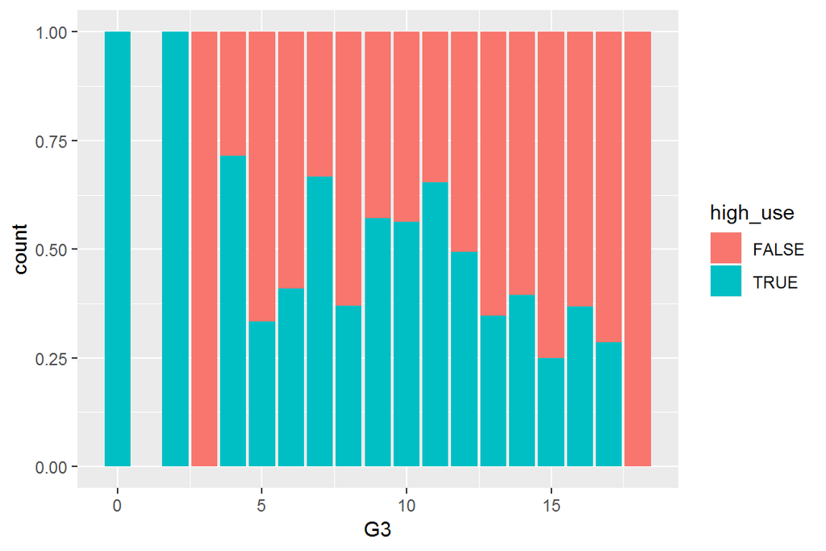

```r
abs <- ggplot(alc, aes(x = G3, fill = high_use)) +
geom_bar(position="fill")
abs
```

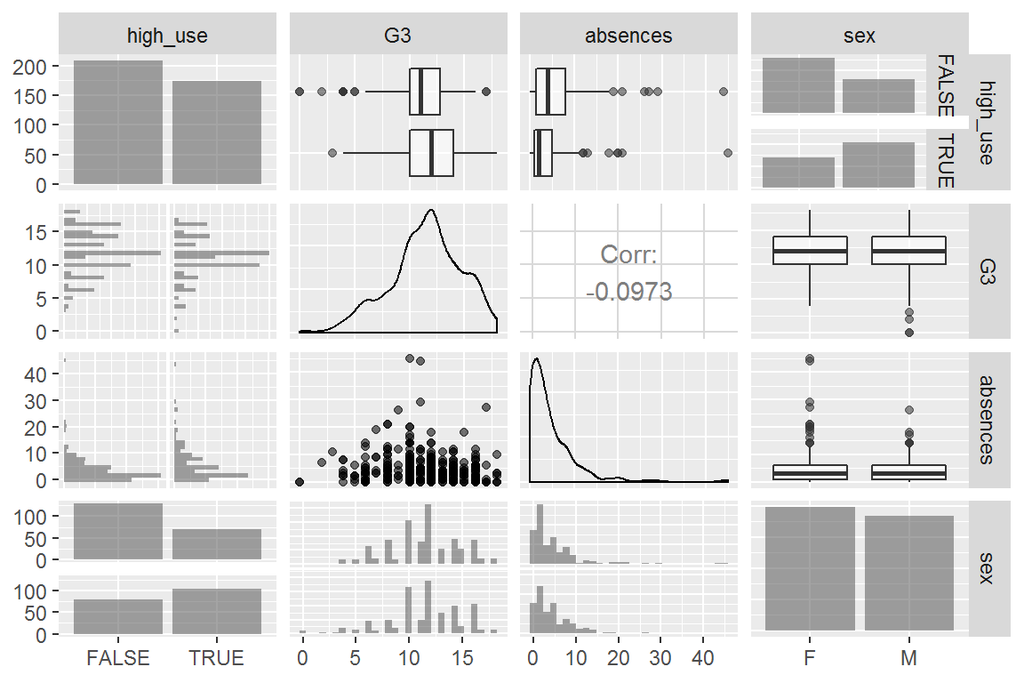

```r
vars <- c("high_use","G3","absences","sex")
ggpairs(alc, columns = vars, mapping = aes(alpha = 0.3), lower = list(combo = wrap("facethist")))
```

- Boxplot show that for males high use is more related to g3 point, for female highuse doesnt really effect.

- From summary we can see that absences and sex are significant variables, G3 is just slightly significant and Pstatus is not at all.

-There are 198 females and 184 male on the data set. propability for a female to be high user is 0.35 and 0.57 for male, so hypothesis was right. From cbind(OR, CI) we can see that odds for men high use are 2.7 times higher then for female.

2.5 Pstatus is not significant so it will be dropped.

```r
m <- glm(high_use ~ absences + sex + Pstatus + G3, data = alc, family = "binomial")

m <- glm(high_use ~ absences + sex + G3, data = alc, family = "binomial")
summary(m)
```

```
##
## Call:
## glm(formula = high_use ~ absences + sex + G3, family = "binomial",
##     data = alc)
##
## Deviance Residuals:
##     Min       1Q   Median       3Q      Max
## -2.2624  -1.0324  -0.7392   1.0978   1.8355
##
## Coefficients:
##             Estimate Std. Error z value Pr(>|z|)
## (Intercept) -0.01459    0.42492  -0.034   0.9726
## absences     0.07455    0.02285   3.263   0.0011 **
## sexM         0.99179    0.21822   4.545  5.5e-06 ***
## G3          -0.08616    0.03350  -2.572   0.0101 *
## ---
## Signif. codes:  0 '***' 0.001 '**' 0.01 '*' 0.05 '.' 0.1 ' ' 1
##
## (Dispersion parameter for binomial family taken to be 1)
##
##     Null deviance: 526.53  on 381  degrees of freedom
## Residual deviance: 486.18  on 378  degrees of freedom
## AIC: 494.18
##
## Number of Fisher Scoring iterations: 4
```

```r
coef(m)
```

```
## (Intercept)    absences        sexM          G3
## -0.01459384  0.07455392  0.99179380 -0.08615843
```

```r
confint(m)
```

```
##                   2.5 %      97.5 %
## (Intercept) -0.84873690  0.82171416
## absences     0.03207927  0.12182000
## sexM         0.56786579  1.42426036
## G3          -0.15289901 -0.02123354
```

```r
OR <- coef(m) %>% exp
CI <- confint(m) %>% exp
cbind(OR, CI)
```

```
##                    OR     2.5 %    97.5 %
## (Intercept) 0.9855121 0.4279551 2.2743952
## absences    1.0774034 1.0325994 1.1295508
## sexM        2.6960663 1.7644972 4.1547837
## G3          0.9174489 0.8582164 0.9789903
```

Pstatus was dropped since it was not significant. in the new model:

-Each point in absences raises the odds for 1.08. for 95% of the students one absence point raises high use risk between 1.03 & 1.13.

- In sex its 2.7 times more likely for male to be high user than female. for 95% of the students the coefficients have an effect of 1.76-4.15
- Each point in G3 decreases the risk for high use for 1-0.92. for 95% of the students the one point decreases between 0.86 and 0.98.

3.6

```r
m <- glm(high_use ~ absences + Pstatus + sex + G3, data = alc, family = "binomial")
probabilities <- predict(m, type = "response")
alc <- mutate(alc, probability = probabilities)
alc <- mutate(alc, prediction = alc$probability>0.5)
select(alc, G3, absences, sex, high_use, probability, prediction) %>% tail(10)
```

```
##     G3 absences sex high_use probability prediction
## 373  0        0   M     TRUE   0.7236687       TRUE
## 374  2        7   M     TRUE   0.7936071       TRUE
## 375 12        1   F     TRUE   0.2823117      FALSE
## 376  8        6   F     TRUE   0.4471281      FALSE
## 377  5        2   F    FALSE   0.4306905      FALSE
## 378 12        2   F    FALSE   0.2984561      FALSE
## 379  4        2   F     TRUE   0.4509577      FALSE
## 380  4        3   F    FALSE   0.4704247      FALSE
## 381 13        4   M     TRUE   0.5516064       TRUE
## 382 10        2   M     TRUE   0.5737420       TRUE
```

```r
table(high_use = alc$high_use, prediction = alc$prediction)
```

```
##         prediction
## high_use FALSE TRUE
##    FALSE   151   57
##    TRUE     79   95
```

```r
table(high_use = alc$high_use, prediction = alc$prediction) %>% prop.table() %>% addmargins()
```

```
##         prediction
## high_use     FALSE      TRUE       Sum
##    FALSE 0.3952880 0.1492147 0.5445026
##    TRUE  0.2068063 0.2486911 0.4554974
##    Sum   0.6020942 0.3979058 1.0000000
```

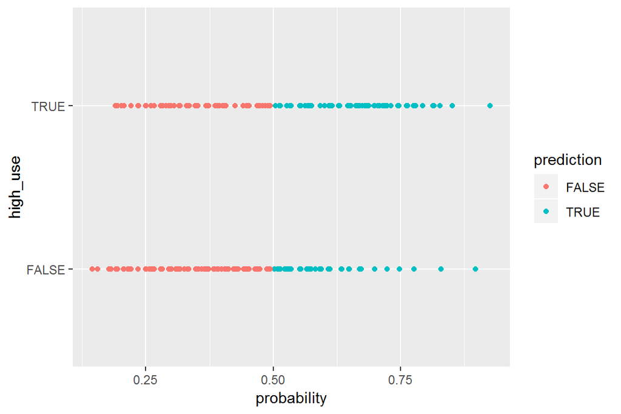

```r
g <- ggplot(alc, aes(x = probability, y = high_use, col=prediction))
g + geom_point()
```

prediction says 0.60 for false, 0.40 for true. high_use is 0.54 for false and 46 for true. I will add failures to model to see what happens

```r
m <- glm(high_use ~ absences + failures + sex + G3, data = alc, family = "binomial")
probabilities <- predict(m, type = "response")
alc <- mutate(alc, probability = probabilities)
alc <- mutate(alc, prediction = alc$probability>0.5)
select(alc, G3, absences, sex, high_use, probability, prediction) %>% tail(10)
```

```
##     G3 absences sex high_use probability prediction
## 373  0        0   M     TRUE   0.7322418       TRUE
## 374  2        7   M     TRUE   0.8001864       TRUE
## 375 12        1   F     TRUE   0.2669667      FALSE
## 376  8        6   F     TRUE   0.4053126      FALSE
## 377  5        2   F    FALSE   0.4649528      FALSE
## 378 12        2   F    FALSE   0.2815204      FALSE
## 379  4        2   F     TRUE   0.5657591       TRUE
## 380  4        3   F    FALSE   0.4153810      FALSE
## 381 13        4   M     TRUE   0.5276033       TRUE
## 382 10        2   M     TRUE   0.5399197       TRUE
```

```r
table(high_use = alc$high_use, prediction = alc$prediction)
```

```
##         prediction
## high_use FALSE TRUE
##    FALSE   158   50
##    TRUE     80   94
```

```r
table(high_use = alc$high_use, prediction = alc$prediction) %>% prop.table() %>% addmargins()
```

```
##         prediction
## high_use     FALSE      TRUE       Sum
##    FALSE 0.4136126 0.1308901 0.5445026
##    TRUE  0.2094241 0.2460733 0.4554974
##    Sum   0.6230366 0.3769634 1.0000000
```

define a loss function (mean prediction error)/proportion of inaccurately classified individuals (= the training error):

```r
loss_func <- function(class, prob) {
  n_wrong <- abs(class - prob) > 0.5
  mean(n_wrong)
}
loss_func(class = alc$high_use, prob = alc$probability)
```

```
## [1] 0.3403141
```

The training error is 0.34, so it´s worse then the one in dataCamp exercises.

Bonus:

```r
loss_func(class = alc$high_use, prob = alc$probability)
```

```
## [1] 0.3403141
```

```r
library(boot)
cv <- cv.glm(data = alc, cost = loss_func, glmfit = m, K = 10)
cv$delta[1]
```

```
## [1] 0.382199
```

Chapter 4 - Clustering and classification Analysis 4.1.

```r
library(MASS)
```

```r
library(dplyr)
library(GGally)
library(ggplot2)
library(tidyverse)
library(corrplot)
bhv <- Boston
str(bhv)
```

```
## 'data.frame':    506 obs. of  14 variables:
##  $ crim   : num  0.00632 0.02731 0.02729 0.03237 0.06905 ...
##  $ zn     : num  18 0 0 0 0 0 12.5 12.5 12.5 12.5 ...
##  $ indus  : num  2.31 7.07 7.07 2.18 2.18 2.18 7.87 7.87 7.87 7.87 ...
##  $ chas   : int  0 0 0 0 0 0 0 0 0 0 ...
##  $ nox    : num  0.538 0.469 0.469 0.458 0.458 0.458 0.524 0.524 0.524 0.524 ...
##  $ rm     : num  6.58 6.42 7.18 7 7.15 ...
##  $ age    : num  65.2 78.9 61.1 45.8 54.2 58.7 66.6 96.1 100 85.9 ...
##  $ dis    : num  4.09 4.97 4.97 6.06 6.06 ...
##  $ rad    : int  1 2 2 3 3 3 5 5 5 5 ...
##  $ tax    : num  296 242 242 222 222 222 311 311 311 311 ...
##  $ ptratio: num  15.3 17.8 17.8 18.7 18.7 18.7 15.2 15.2 15.2 15.2 ...
##  $ black  : num  397 397 393 395 397 ...
##  $ lstat  : num  4.98 9.14 4.03 2.94 5.33 ...
##  $ medv   : num  24 21.6 34.7 33.4 36.2 28.7 22.9 27.1 16.5 18.9 ...
```

```r
dim(bhv)
```

```
## [1] 506  14
```

The data is about housing values in suburbs of Boston and table has 14 variables and 506 observations. THe variables: < code >crim per capita crime rate by town. < code >zn proportion of residential land zoned for lots over 25,000 sq.ft. < code >indus proportion of non-retail business acres per town. < code >chas Charles River dummy variable (= 1 if tract bounds river; 0 otherwise). < code >nox nitrogen oxides concentration (parts per 10 million). < code >rm average number of rooms per dwelling. < code >age proportion of owner-occupied units built prior to 1940. < code >dis weighted mean of distances to five Boston employment centres. < code >rad index of accessibility to radial highways. < code >tax full-value property-tax rate per $10,000. < code >ptratio pupil-teacher ratio by town. < code >black 1000(Bk - 0.63)^2 where Bk is the proportion of blacks by town. < code >lstat lower status of the population (percent). < code >medv median value of owner-occupied homes in $1000s.

Lets change the variable names to more understandable ones.

```r
new_names <- c("crime_rate","proposion_residental_land", "proportion_industrial", "river_bound", "Nitrogen_concentration", "rooms_per_house", "proportion_old_houses","distance_emplyment_center", "access_highways","tax_value", "pupil_teacher_ratio", "proportion_blacks", "lower_status", "house_values")
names(bhv) <-new_names
summary(bhv)
```

```
##    crime_rate       proposion_residental_land proportion_industrial
##  Min.   : 0.00632   Min.   :  0.00            Min.   : 0.46
##  1st Qu.: 0.08204   1st Qu.:  0.00            1st Qu.: 5.19
##  Median : 0.25651   Median :  0.00            Median : 9.69
##  Mean   : 3.61352   Mean   : 11.36            Mean   :11.14
##  3rd Qu.: 3.67708   3rd Qu.: 12.50            3rd Qu.:18.10
##  Max.   :88.97620   Max.   :100.00            Max.   :27.74
##   river_bound      Nitrogen_concentration rooms_per_house
##  Min.   :0.00000   Min.   :0.3850         Min.   :3.561
##  1st Qu.:0.00000   1st Qu.:0.4490         1st Qu.:5.886
##  Median :0.00000   Median :0.5380         Median :6.208
##  Mean   :0.06917   Mean   :0.5547         Mean   :6.285
##  3rd Qu.:0.00000   3rd Qu.:0.6240         3rd Qu.:6.623
##  Max.   :1.00000   Max.   :0.8710         Max.   :8.780
##  proportion_old_houses distance_emplyment_center access_highways
##  Min.   :  2.90        Min.   : 1.130            Min.   : 1.000
##  1st Qu.: 45.02        1st Qu.: 2.100            1st Qu.: 4.000
##  Median : 77.50        Median : 3.207            Median : 5.000
##  Mean   : 68.57        Mean   : 3.795            Mean   : 9.549
##  3rd Qu.: 94.08        3rd Qu.: 5.188            3rd Qu.:24.000
##  Max.   :100.00        Max.   :12.127            Max.   :24.000
##    tax_value     pupil_teacher_ratio proportion_blacks  lower_status
##  Min.   :187.0   Min.   :12.60       Min.   :  0.32    Min.   : 1.73
##  1st Qu.:279.0   1st Qu.:17.40       1st Qu.:375.38    1st Qu.: 6.95
##  Median :330.0   Median :19.05       Median :391.44    Median :11.36
##  Mean   :408.2   Mean   :18.46       Mean   :356.67    Mean   :12.65
##  3rd Qu.:666.0   3rd Qu.:20.20       3rd Qu.:396.23    3rd Qu.:16.95
##  Max.   :711.0   Max.   :22.00       Max.   :396.90    Max.   :37.97
##   house_values
##  Min.   : 5.00
##  1st Qu.:17.02
##  Median :21.20
##  Mean   :22.53
##  3rd Qu.:25.00
##  Max.   :50.00
```

[figure not shown]

```r
ggpairs(bhv, columns = 1:14, mapping = aes(alpha = 0.3), lower = list(combo = wrap("facethist")))
```

[figure not shown]

```r
cor_matrix <- cor(Boston)
cor_matrix_rounded<-cor(bhv) %>% round(2)

corrplot(cor_matrix, method="number", type = "upper", cl.pos = "b", tl.pos = "a", tl.cex = 0.6)
```

-We dont know how the propotion of blacks is counted but from summary we can see that it´s heavily left skewed, minimum is 0.32, 1st qu 375.38 and Mean 356.67. This implies that there are few areas that have extremely small percentage of black people. -Crime rate seems to changing a lot, min is 0.00632, median 0.25651 and max 88.97620! So in some places 1000 people get caught/prosecuted from crimes 6.32 times, in the median area it´s 256.51 times and the maximum is 88976.20? So every citizen would make 89 crimes? I guess that can’t be right so im assuming this cant be directly read as amount of crimes. So according the data in some suburbs per capita there is 14000 times more crime then in others. In the correlation matrix we can see that the variables that correlate most are access to highways 0.6255 and tax value 0.5827. - Tax value correlates strongly with access to highways 0.9102 and propotion industrial 0.7207 -House values correlate with lower status -0.74 and 0.70 on rooms per house.

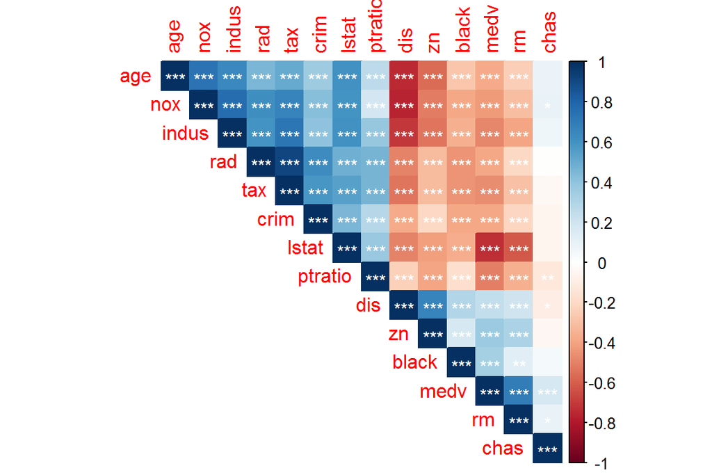

```r
res1 <- cor.mtest(Boston, conf.level = .95)
corrplot(cor_matrix, p.mat = res1$p, method = "color", type = "upper",
         sig.level = c(.001, .01, .05), pch.cex = .9,
         insig = "label_sig", pch.col = "white", order = "AOE")
```

```r
asd <- c(bhv$access_highways==24)
asb <- c(bhv$tax_value==666)
length(which(asb))
```

```
## [1] 132
```

```r
length(which(asd))
```

```
## [1] 132
```

```r
sum(asd,na.rm=T)
```

```
## [1] 132
```

4.2 Standardize the dataset and print out summaries of the scaled data. How did the variables change? Create a categorical variable of the crime rate in the Boston dataset (from the scaled crime rate). Use the quantiles as the break points in the categorical variable. Drop the old crime rate variable from the dataset. Divide the dataset to train and test sets, so that 80% of the data belongs to the train set.

```r
bhv_scaled <- scale(bhv)
summary(bhv_scaled)
```

```
##    crime_rate        proposion_residental_land proportion_industrial
##  Min.   :-0.419367   Min.   :-0.48724          Min.   :-1.5563
##  1st Qu.:-0.410563   1st Qu.:-0.48724          1st Qu.:-0.8668
##  Median :-0.390280   Median :-0.48724          Median :-0.2109
##  Mean   : 0.000000   Mean   : 0.00000          Mean   : 0.0000
##  3rd Qu.: 0.007389   3rd Qu.: 0.04872          3rd Qu.: 1.0150
##  Max.   : 9.924110   Max.   : 3.80047          Max.   : 2.4202
##   river_bound      Nitrogen_concentration rooms_per_house
##  Min.   :-0.2723   Min.   :-1.4644        Min.   :-3.8764
##  1st Qu.:-0.2723   1st Qu.:-0.9121        1st Qu.:-0.5681
##  Median :-0.2723   Median :-0.1441        Median :-0.1084
##  Mean   : 0.0000   Mean   : 0.0000        Mean   : 0.0000
##  3rd Qu.:-0.2723   3rd Qu.: 0.5981        3rd Qu.: 0.4823
##  Max.   : 3.6648   Max.   : 2.7296        Max.   : 3.5515
##  proportion_old_houses distance_emplyment_center access_highways
##  Min.   :-2.3331       Min.   :-1.2658           Min.   :-0.9819
##  1st Qu.:-0.8366       1st Qu.:-0.8049           1st Qu.:-0.6373
##  Median : 0.3171       Median :-0.2790           Median :-0.5225
##  Mean   : 0.0000       Mean   : 0.0000           Mean   : 0.0000
##  3rd Qu.: 0.9059       3rd Qu.: 0.6617           3rd Qu.: 1.6596
##  Max.   : 1.1164       Max.   : 3.9566           Max.   : 1.6596
##    tax_value       pupil_teacher_ratio proportion_blacks  lower_status
##  Min.   :-1.3127   Min.   :-2.7047     Min.   :-3.9033   Min.   :-1.5296
##  1st Qu.:-0.7668   1st Qu.:-0.4876     1st Qu.: 0.2049   1st Qu.:-0.7986
##  Median :-0.4642   Median : 0.2746     Median : 0.3808   Median :-0.1811
##  Mean   : 0.0000   Mean   : 0.0000     Mean   : 0.0000   Mean   : 0.0000
##  3rd Qu.: 1.5294   3rd Qu.: 0.8058     3rd Qu.: 0.4332   3rd Qu.: 0.6024
##  Max.   : 1.7964   Max.   : 1.6372     Max.   : 0.4406   Max.   : 3.5453
##   house_values
##  Min.   :-1.9063
##  1st Qu.:-0.5989
##  Median :-0.1449
##  Mean   : 0.0000
##  3rd Qu.: 0.2683
##  Max.   : 2.9865
```

```r
class(bhv_scaled)
```

```
## [1] "matrix"
```

```r
bhv_scaled=as.data.frame(bhv_scaled)
```

-bhv_scaled was matrix so it´s turned into data frame. -Scaling substracts the mean of the column from each row, and then divides the difference with standard deviation. What we get is that all the variables are on similar scale. - Scaling is necessary for the later linear discriminant analysis, because it assumes the variables are normally distributed and each variable has same variance.

```r
bins <- quantile(bhv_scaled$crime_rate)
bins
```

```
##           0%          25%          50%          75%         100%
## -0.419366929 -0.410563278 -0.390280295  0.007389247  9.924109610
```

- Makes quantiles, median is -0.3902. 25% is -0,4105 and 75% 0,0073, so between these to error is 50% of the suburbs in data. breaks = 4 had to be changed to “bins”

```r
labels <- c("low", "med_low", "med_high", "high")
crime_rate <- cut(bhv_scaled$crime_rate, breaks =bins, include.lowest = TRUE, label = labels)
table(crime_rate)
```

```
## crime_rate
##      low  med_low med_high     high
##      127      126      126      127
```

```r
bhv_scaled <- dplyr::select(bhv_scaled, -crime_rate)
bhv_scaled <- data.frame(crime_rate, bhv_scaled)
```

-Tells how many people are in which group. - dropped the old criminal rate as the first column. - Dividing the data to test and train data 20/80%.The training of the model is done with the train set and prediction on new data is done with the test set. This way you have true classes / labels for the test data, and you can calculate how well the model performed in prediction.

```r
# number of rows in the Boston dataset
n <- nrow(bhv_scaled)

# choose randomly 80% of the rows
ind <- sample(n,  size = n * 0.8)

# create train set
train <- bhv_scaled[ind,]

# create test set
test <- bhv_scaled[-ind,]

# save the correct classes from test data
correct_classes <- test$crime
# remove the crime variable from test data
test <- dplyr::select(test, -crime_rate)
```

4.5 LDA is used to predict classes for new data and to find variables that either discriminate or separate the classes best (DataCamp). The difference between classification and clustering is, that in classification the classes are known and the model is trained with the training set from the data, and it classifies new values into classes. Clustering, on the other hand, means that the classes are unknown, but the data is grouped based on the similarities of the observations. If the assumptions of discriminant analysis are met, it is more powerful than logistic regression, but the assumptions are rarely met.

```r
lda.fit <- lda(crime_rate ~ ., data = train)
# print the lda.fit object
lda.fit
```

```
## Call:
## lda(crime_rate ~ ., data = train)
##
## Prior probabilities of groups:
##       low   med_low  med_high      high
## 0.2549505 0.2524752 0.2450495 0.2475248
##
## Group means:
##          proposion_residental_land proportion_industrial river_bound
## low                      0.9079319            -0.9519001 -0.08120770
## med_low                 -0.1044987            -0.2382994  0.03646311
## med_high                -0.3910915             0.2096498  0.20489520
## high                    -0.4872402             1.0171519 -0.03610305
##          Nitrogen_concentration rooms_per_house proportion_old_houses
## low                  -0.8848376       0.4259202            -0.9057997
## med_low              -0.5324239      -0.1573906            -0.3167822
## med_high              0.4417920       0.1265283             0.4300315
## high                  1.0401049      -0.3584233             0.8185446
##          distance_emplyment_center access_highways  tax_value
## low                      0.8904083      -0.6785867 -0.7342122
## med_low                  0.3262820      -0.5517590 -0.4860272
## med_high                -0.3792810      -0.4145981 -0.3022730
## high                    -0.8632103       1.6377820  1.5138081
##          pupil_teacher_ratio proportion_blacks lower_status house_values
## low              -0.44719599        0.38308227  -0.75888953   0.50925797
## med_low          -0.08588011        0.31667683  -0.11015066  -0.01369383
## med_high         -0.29952850        0.07338867   0.01510222   0.17325631
## high              0.78037363       -0.94400416   0.91078011  -0.66736293
##
## Coefficients of linear discriminants:
##                                   LD1          LD2         LD3
## proposion_residental_land  0.11952255  0.668825074 -0.87705788
## proportion_industrial      0.10222215 -0.383274151  0.50056080
## river_bound               -0.08468154 -0.033276958  0.11593446
## Nitrogen_concentration     0.35297476 -0.802588440 -1.40976563
## rooms_per_house           -0.04680548 -0.119606859 -0.19584210
## proportion_old_houses      0.26490849 -0.358276558 -0.06787799
## distance_emplyment_center -0.04684073 -0.358454453  0.16966041
## access_highways            3.18222146  0.979027256  0.03682149
## tax_value                 -0.03690863  0.024636651  0.34441970
## pupil_teacher_ratio        0.13530957 -0.037675458 -0.31692444
## proportion_blacks         -0.12460092  0.005601159  0.11935432
## lower_status               0.25068484 -0.154714293  0.32874749
## house_values               0.21396755 -0.358913723 -0.22931423
##
## Proportion of trace:
##    LD1    LD2    LD3
## 0.9452 0.0420 0.0127
```

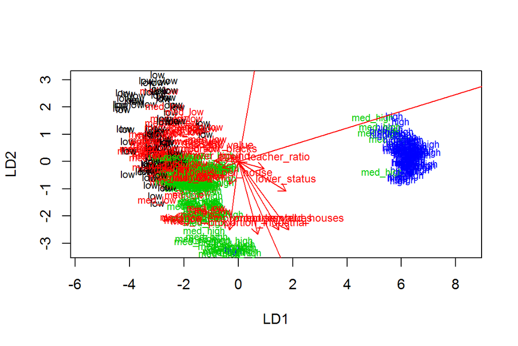

```r
# the function for lda biplot arrows
lda.arrows <- function(x, myscale = 1, arrow_heads = 0.1, color = "red", tex = 0.75, choices = c(1,2)){
  heads <- coef(x)
  arrows(x0 = 0, y0 = 0,
         x1 = myscale * heads[,choices[1]],
         y1 = myscale * heads[,choices[2]], col=color, length = arrow_heads)
  text(myscale * heads[,choices], labels = row.names(heads),
       cex = tex, col=color, pos=3)
}
# target classes as numeric
classes <- as.numeric(train$crime_rate)
# plot the lda results
plot(lda.fit, dimen = 2,col = classes, pch = classes)
lda.arrows(lda.fit, myscale = 7)
```

```r
# or like this: plot(lda.fit, dimen = 2,col = classes, pch = classes) + lda.arrows(lda.fit, myscale = 7)
```

- these have to be run similarily in RMarkdown, maybe because when you call arrow it removes above lda and there is nowhere to draw the lines.